# **Customer Segmentation Analysis**

## Plot the graphs

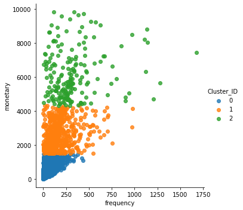

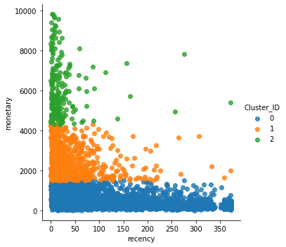

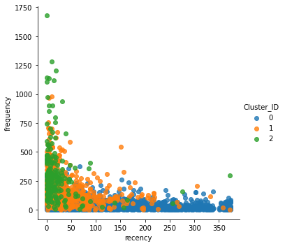

```python
# Create a plot for frequency vs monetary
facet = sns.lmplot(data=X, x='frequency', y='monetary', hue='Cluster_ID',
                   fit_reg=False, legend=True, legend_out=True)
# Create a plot for recency vs monetary
facet2 = sns.lmplot(data=X, x='recency', y='monetary', hue='Cluster_ID',
                   fit_reg=False, legend=True, legend_out=True)
# Create a plot for recency vs frequency
facet2 = sns.lmplot(data=X, x='recency', y='frequency', hue='Cluster_ID',
                   fit_reg=False, legend=True, legend_out=True)
```

### Q 24. Comment on the plots

We have three clusters 0,1,2. We see the distribution of these clusters within a combination of two variables.

**Recency vs. Monetary**

**Recency vs. frequency**

The graph is no longer layered and all the clusters seem to overlap each other. Graph is highly concentrated towards 0-100 recency and 0-400 frequency distribution.

### Q 25. Perform Cluster Analysis with k=4

```python
# Fitting K Means to the Datatset using k = 4

kmeans2 = KMeans(n_clusters = 4)
y_kmeans2 = kmeans2.fit_predict(X)

rfm['Cluster_ID2'] = y_kmeans2
```

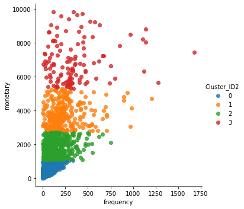

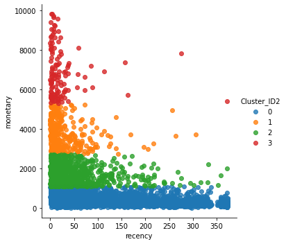

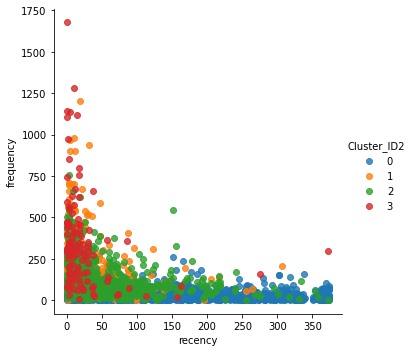

```python
# Create a plot for frequency vs monetary
facet4 = sns.lmplot(data=X, x='frequency', y='monetary', hue='Cluster_ID2',
                   fit_reg=False, legend=True, legend_out=True)
# Create a plot for recency vs monetary
facet5 = sns.lmplot(data=X, x='recency', y='monetary', hue='Cluster_ID2',
                   fit_reg=False, legend=True, legend_out=True)
# Create a plot for recency vs frequency
facet6 = sns.lmplot(data=X, x='recency', y='frequency', hue='Cluster_ID2',
                   fit_reg=False, legend=True, legend_out=True)
```

**The Graph are similar to the graphs for 3 clusters with some more elaborated data points.**

### Q 26. Perform cluster analysis with the outliers removed rfm dataframe. Follow exactly the same steps including the elbow method and plot the graphs and comment on the plots. You decide what k value you should use.

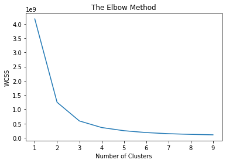

```python
X1 = rfm_clean
# Choose number of Clusters using the elbow method
# Within cluster sum of squares (wcss)
from sklearn.cluster import KMeans
# start with 10 number of clusters
wcss_x1= []
for i in range(1,10):
    kmeans_x1 = KMeans(n_clusters =i, init = 'k-means++', max_iter =300, n_init =10, random_state =0)
    kmeans_x1.fit(X1)
    wcss_x1.append(kmeans_x1.inertia_)
plt.plot(range(1,10), wcss_x1)
plt.title('The Elbow Method')
plt.xlabel('Number of Clusters')
plt.ylabel('WCSS')
plt.show()
```

```python
# Fitting K Means to the Datatset using k = 3

kmeans_x1 = KMeans(n_clusters = 3)
y_kmeans_x1 = kmeans_x1.fit_predict(X1)

X1['Cluster_ID'] = y_kmeans_x1
```

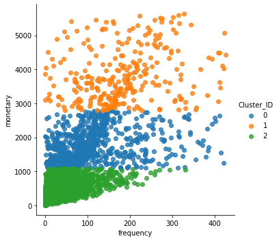

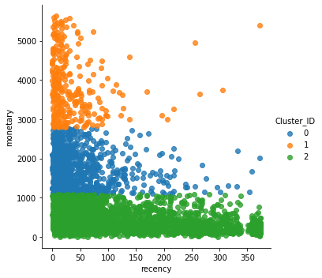

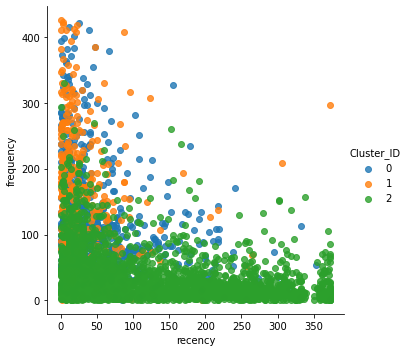

```python
# Create a plot for frequency vs monetary
facet = sns.lmplot(data=X1, x='frequency', y='monetary', hue='Cluster_ID',
                   fit_reg=False, legend=True, legend_out=True)
# Create a plot for recency vs monetary
facet2 = sns.lmplot(data=X1, x='recency', y='monetary', hue='Cluster_ID',
                   fit_reg=False, legend=True, legend_out=True)
# Create a plot for recency vs frequency
facet2 = sns.lmplot(data=X1, x='recency', y='frequency', hue='Cluster_ID',
                   fit_reg=False, legend=True, legend_out=True)
```

We have three clusters in cleaned data as we had in the original data 0,1,2.

**Frequency vs. Monetary**: The clusters are layered. Cluster 2 is the lowest layer, the green cluster has low frequency as well as low monetary value (range: frequency(0-300), monetary(0-1000), these customers are not frequent customers, must be buying odd products and spending less. Cluster 0, is the next up , the blue cluster, these customers are spending more and 25% among them have more frequency. They are spending in the range of 1000-2800, they have higher frequency to green cluster however around 1% of these have frequency morethan 350. Cluster 1, the orange cluster has the highest monetary distribution. Their spending ranges from 2800-5500. There frequency matches that of other blue cluster.

**Recency vs. Monetary**

Negative relationship between Recency and monetary. As recency increases the monetary decreases. That implies that most of the purchases are from recent purchases. There are some orders that were placed nearly a year ago. The clusters are layered. Cluster 2 is at lower layer, the green cluster has high recency, orders are old, and have low monetary value (range: recency(0-400), monetary(0-1000), these orders were old, only 30% of recent orders have a monetary value between (0-1800). Blue cluster is the customers that have purchased within last six months, they have spend moderately between 1000 - 2800. Orange cluster, with maximum spending are customers who have spend recently within less than 50 days. Only very few purchases are out of this distribution and were older purchases.

**Recency vs. frequency**

Lie the original graph, this graph is no longer layered and all the clusters seem to overlap each other. Graph is highly concentrated towards 0-100 recency and 0-250 frequency distribution. This graph is similar to original except the distribution is smaller.

### Calculate mean for every cluster

```python
# Calculate mean for every cluster
for i in range(4):
    rfm_clean_mean= rfm_clean.groupby(['Cluster_ID']).mean()

rfm_clean_mean
```

| Cluster_ID | recency | frequency | monetary |
| --- | --- | --- | --- |
| 0 | 48.717391 | 110.737923 | 1739.490338 |
| 1 | 33.644599 | 183.926829 | 3828.595819 |
| 2 | 118.807632 | 35.664720 | 433.883956 |

## Perform cluster analysis using hierarchical clustering with the cleaned rfm dataframe

```python
# Import the libraries
import scipy.cluster.hierarchy as sch
```

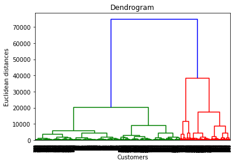

```python
# Build a dendrogram using the minimum variance method
dendrogram = sch.dendrogram(sch.linkage(X1, method = 'ward'))
plt.title('Dendrogram')
plt.xlabel('Customers')
plt.ylabel('Euclidean distances')
plt.show()
```

## Identify the clusters based on dendrogram

```python
# Train the hierarchical clustering model on the dataset
from sklearn.cluster import AgglomerativeClustering
hc = AgglomerativeClustering(n_clusters = 2, affinity = 'euclidean', linkage = 'ward')
y_hc = hc.fit_predict(X1)
```

```python
X1['Cluster_ID'] = y_hc
```

```python
X1.head()
```

| CustomerID | recency | frequency | monetary | Cluster_ID |
| --- | --- | --- | --- | --- |
| 13256.0 | 14 | 1 | 0 | 1 |
| 16738.0 | 297 | 1 | 3 | 1 |
| 16454.0 | 44 | 2 | 6 | 1 |
| 14792.0 | 63 | 2 | 6 | 1 |
| 17956.0 | 249 | 1 | 12 | 1 |

### Q. Create all the three plots again. Do you observe any differences from k-means clustering method

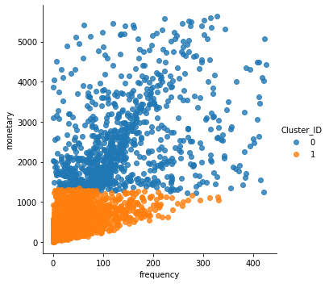

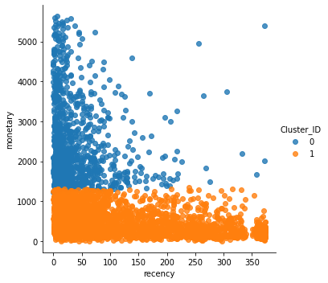

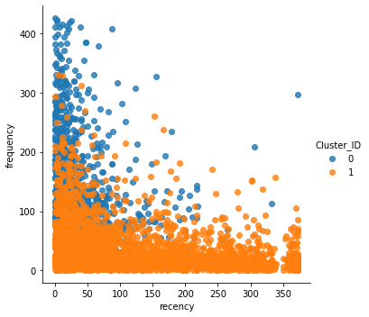

```python
# Create a plot for frequency vs monetary
facet = sns.lmplot(data=X1, x='frequency', y='monetary', hue='Cluster_ID',
                   fit_reg=False, legend=True, legend_out=True)
# Create a plot for recency vs monetary
facet2 = sns.lmplot(data=X1, x='recency', y='monetary', hue='Cluster_ID',
                   fit_reg=False, legend=True, legend_out=True)
# Create a plot for recency vs frequency
facet2 = sns.lmplot(data=X1, x='recency', y='frequency', hue='Cluster_ID',
                   fit_reg=False, legend=True, legend_out=True)
```

#### Difference

For above graphs, it has only taken two clusters.

## Evaluate Clustering

```python
# Import libraries
from sklearn import cluster
from sklearn import metrics
```

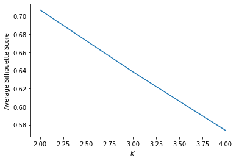

```python
# Calculate Silhouette score for different cluster values
krange = list(range(2,5))
avg_silhouettes = []
for n in krange:
    model = cluster.KMeans(n_clusters=n, random_state=10)
    cluster_assignments = model.fit_predict(X1)

    silhouette_avg = metrics.silhouette_score(X1, cluster_assignments)
    avg_silhouettes.append(silhouette_avg)

    # PLot the score
plt.plot(krange, avg_silhouettes)
plt.xlabel("$K$")
plt.ylabel("Average Silhouette Score")
plt.show()
```

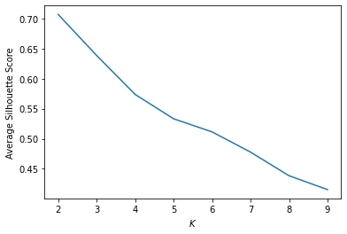

```python
# Calculate Silhouette score for different cluster values
krange = list(range(2,10))
avg_silhouettes = []
for n in krange:
    model = cluster.KMeans(n_clusters=n, random_state=10)
    cluster_assignments = model.fit_predict(X1)

    silhouette_avg = metrics.silhouette_score(X1, cluster_assignments)
    avg_silhouettes.append(silhouette_avg)

    # PLot the score
plt.plot(krange, avg_silhouettes)
plt.xlabel("$K$")
plt.ylabel("Average Silhouette Score")
plt.show()
```

According to Silhouette principle, we are trying to assess if data points have been appropriately mapped to their own clusters when compared to the other clusters. Also we try to establish that which is the optimum cluster size, as the size of the clusters are increasing Silhouette score is decreasing that means data points are not being mapped to their own clusters properly. Having few clusters like K=2, would split the data in only two parts resulting in not much clarification or information gain. Having 4 clusters will give more information but it might not be true as compared with its pairs. In a nut shell, K=3 is perhaps the best cluster size given the data and is providing best insights.

```python
%%shell
ipython nbconvert --to html  HSPA_Classififcation.ipynb
```